# Soluzione - Tutorato 5

Caricare il dataset `marketing_campaign.csv` (che trovate anche su [Kaggle](https://www.kaggle.com/datasets/imakash3011/customer-personality-analysis?resource=download))

```r
# Carico il dataset
marketing <- read.csv("marketing_campaign.csv", sep = "\t")

# Struttura del dataset
str(marketing)
```

```
## 'data.frame':    2240 obs. of  29 variables:
##  $ ID                 : int  5524 2174 4141 6182 5324 7446 965 6177 4855 5899 ...
##  $ Year_Birth         : int  1957 1954 1965 1984 1981 1967 1971 1985 1974 1950 ...
##  $ Education          : chr  "Graduation" "Graduation" "Graduation" "Graduation" ...
##  $ Marital_Status     : chr  "Single" "Single" "Together" "Together" ...
##  $ Income             : int  58138 46344 71613 26646 58293 62513 55635 33454 30351 5648 ...
##  $ Kidhome            : int  0 1 0 1 1 0 0 1 1 1 ...
##  $ Teenhome           : int  0 1 0 0 0 1 1 0 0 1 ...
##  $ Dt_Customer        : chr  "04-09-2012" "08-03-2014" "21-08-2013" "10-02-2014" ...
##  $ Recency            : int  58 38 26 26 94 16 34 32 19 68 ...
##  $ MntWines           : int  635 11 426 11 173 520 235 76 14 28 ...
##  $ MntFruits          : int  88 1 49 4 43 42 65 10 0 0 ...
##  $ MntMeatProducts    : int  546 6 127 20 118 98 164 56 24 6 ...
##  $ MntFishProducts    : int  172 2 111 10 46 0 50 3 3 1 ...
##  $ MntSweetProducts   : int  88 1 21 3 27 42 49 1 3 1 ...
##  $ MntGoldProds       : int  88 6 42 5 15 14 27 23 2 13 ...
##  $ NumDealsPurchases  : int  3 2 1 2 5 2 4 2 1 1 ...
##  $ NumWebPurchases    : int  8 1 8 2 5 6 7 4 3 1 ...
##  $ NumCatalogPurchases: int  10 1 2 0 3 4 3 0 0 0 ...
##  $ NumStorePurchases  : int  4 2 10 4 6 10 7 4 2 0 ...
##  $ NumWebVisitsMonth  : int  7 5 4 6 5 6 6 8 9 20 ...
##  $ AcceptedCmp3       : int  0 0 0 0 0 0 0 0 0 1 ...
##  $ AcceptedCmp4       : int  0 0 0 0 0 0 0 0 0 0 ...
##  $ AcceptedCmp5       : int  0 0 0 0 0 0 0 0 0 0 ...
##  $ AcceptedCmp1       : int  0 0 0 0 0 0 0 0 0 0 ...
##  $ AcceptedCmp2       : int  0 0 0 0 0 0 0 0 0 0 ...
##  $ Complain           : int  0 0 0 0 0 0 0 0 0 0 ...
##  $ Z_CostContact      : int  3 3 3 3 3 3 3 3 3 3 ...
##  $ Z_Revenue          : int  11 11 11 11 11 11 11 11 11 11 ...
##  $ Response           : int  1 0 0 0 0 0 0 0 1 0 ...
```

```r
# Prime righe
head(marketing)
```

```
##     ID Year_Birth  Education Marital_Status Income Kidhome Teenhome Dt_Customer
## 1 5524       1957 Graduation         Single  58138       0        0  04-09-2012
## 2 2174       1954 Graduation         Single  46344       1        1  08-03-2014
## 3 4141       1965 Graduation       Together  71613       0        0  21-08-2013
## 4 6182       1984 Graduation       Together  26646       1        0  10-02-2014
## 5 5324       1981        PhD        Married  58293       1        0  19-01-2014
## 6 7446       1967     Master       Together  62513       0        1  09-09-2013
##   Recency MntWines MntFruits MntMeatProducts MntFishProducts MntSweetProducts
## 1      58      635        88             546             172               88
## 2      38       11         1               6               2                1
## 3      26      426        49             127             111               21
## 4      26       11         4              20              10                3
## 5      94      173        43             118              46               27
## 6      16      520        42              98               0               42
##   MntGoldProds NumDealsPurchases NumWebPurchases NumCatalogPurchases
```

[output cut: 20 more lines]

```r
# Statistiche descrittive
summary(marketing)
```

```
##        ID          Year_Birth    Education         Marital_Status
##  Min.   :    0   Min.   :1893   Length:2240        Length:2240
##  1st Qu.: 2828   1st Qu.:1959   Class :character   Class :character
##  Median : 5458   Median :1970   Mode  :character   Mode  :character
##  Mean   : 5592   Mean   :1969
##  3rd Qu.: 8428   3rd Qu.:1977
##  Max.   :11191   Max.   :1996
##
##      Income          Kidhome          Teenhome      Dt_Customer
##  Min.   :  1730   Min.   :0.0000   Min.   :0.0000   Length:2240
##  1st Qu.: 35303   1st Qu.:0.0000   1st Qu.:0.0000   Class :character
##  Median : 51382   Median :0.0000   Median :0.0000   Mode  :character
##  Mean   : 52247   Mean   :0.4442   Mean   :0.5062
##  3rd Qu.: 68522   3rd Qu.:1.0000   3rd Qu.:1.0000
##  Max.   :666666   Max.   :2.0000   Max.   :2.0000
##  NA's   :24
##     Recency         MntWines         MntFruits     MntMeatProducts
##  Min.   : 0.00   Min.   :   0.00   Min.   :  0.0   Min.   :   0.0
##  1st Qu.:24.00   1st Qu.:  23.75   1st Qu.:  1.0   1st Qu.:  16.0
##  Median :49.00   Median : 173.50   Median :  8.0   Median :  67.0
##  Mean   :49.11   Mean   : 303.94   Mean   : 26.3   Mean   : 166.9
##  3rd Qu.:74.00   3rd Qu.: 504.25   3rd Qu.: 33.0   3rd Qu.: 232.0
##  Max.   :99.00   Max.   :1493.00   Max.   :199.0   Max.   :1725.0
##
##  MntFishProducts  MntSweetProducts  MntGoldProds    NumDealsPurchases
##  Min.   :  0.00   Min.   :  0.00   Min.   :  0.00   Min.   : 0.000
##  1st Qu.:  3.00   1st Qu.:  1.00   1st Qu.:  9.00   1st Qu.: 1.000
##  Median : 12.00   Median :  8.00   Median : 24.00   Median : 2.000
##  Mean   : 37.53   Mean   : 27.06   Mean   : 44.02   Mean   : 2.325
##  3rd Qu.: 50.00   3rd Qu.: 33.00   3rd Qu.: 56.00   3rd Qu.: 3.000
##  Max.   :259.00   Max.   :263.00   Max.   :362.00   Max.   :15.000
##
##  NumWebPurchases  NumCatalogPurchases NumStorePurchases NumWebVisitsMonth
##  Min.   : 0.000   Min.   : 0.000      Min.   : 0.00     Min.   : 0.000
##  1st Qu.: 2.000   1st Qu.: 0.000      1st Qu.: 3.00     1st Qu.: 3.000
##  Median : 4.000   Median : 2.000      Median : 5.00     Median : 6.000
##  Mean   : 4.085   Mean   : 2.662      Mean   : 5.79     Mean   : 5.317
##  3rd Qu.: 6.000   3rd Qu.: 4.000      3rd Qu.: 8.00     3rd Qu.: 7.000
##  Max.   :27.000   Max.   :28.000      Max.   :13.00     Max.   :20.000
##
```

[output cut: 9 more lines]

```
##  Min.   :0.00000   Min.   :0.000000   Min.   :3     Min.   :11
##  1st Qu.:0.00000   1st Qu.:0.000000   1st Qu.:3     1st Qu.:11
##  Median :0.00000   Median :0.000000   Median :3     Median :11
##  Mean   :0.01339   Mean   :0.009375   Mean   :3     Mean   :11
##  3rd Qu.:0.00000   3rd Qu.:0.000000   3rd Qu.:3     3rd Qu.:11
##  Max.   :1.00000   Max.   :1.000000   Max.   :3     Max.   :11
##
##     Response
##  Min.   :0.0000
##  1st Qu.:0.0000
##  Median :0.0000
##  Mean   :0.1491
##  3rd Qu.:0.0000
##  Max.   :1.0000
##
```

```r
# Controllo NA
colSums(is.na(marketing))
```

```
##                  ID          Year_Birth           Education      Marital_Status
##                   0                   0                   0                   0
##              Income             Kidhome            Teenhome         Dt_Customer
##                  24                   0                   0                   0
##             Recency            MntWines           MntFruits     MntMeatProducts
##                   0                   0                   0                   0
##     MntFishProducts    MntSweetProducts        MntGoldProds   NumDealsPurchases
##                   0                   0                   0                   0
##     NumWebPurchases NumCatalogPurchases   NumStorePurchases   NumWebVisitsMonth
##                   0                   0                   0                   0
##        AcceptedCmp3        AcceptedCmp4        AcceptedCmp5        AcceptedCmp1
##                   0                   0                   0                   0
##        AcceptedCmp2            Complain       Z_CostContact           Z_Revenue
##                   0                   0                   0                   0
##            Response
##                   0
```

## PARTE A: Preprocessing del dataset

## 🔹 Classificazione delle variabili

- Classificare le principali variabili del dataset; che variabili potrebbero essere più adatte ad una cluster analysis (considerando che l’obiettivo è una *customer personality analysis*, utile per le aziende per comprendere la propria clientela)?

```r
# Variabili qualitative
unique(marketing$Education)
```

```
## [1] "Graduation" "PhD"        "Master"     "Basic"      "2n Cycle"
```

```r
unique(marketing$Marital_Status)
```

```
## [1] "Single"   "Together" "Married"  "Divorced" "Widow"    "Alone"    "Absurd"
## [8] "YOLO"
```

```r
# Variabili quantitative
summary(marketing[, c("Income", "Year_Birth", "Recency",
                       "MntWines", "MntFruits", "MntMeatProducts",
                       "MntFishProducts", "MntSweetProducts", "MntGoldProds",
                       "NumDealsPurchases", "NumWebPurchases",
                       "NumCatalogPurchases", "NumStorePurchases",
                       "NumWebVisitsMonth")])
```

```
##      Income         Year_Birth      Recency         MntWines
##  Min.   :  1730   Min.   :1893   Min.   : 0.00   Min.   :   0.00
##  1st Qu.: 35303   1st Qu.:1959   1st Qu.:24.00   1st Qu.:  23.75
##  Median : 51382   Median :1970   Median :49.00   Median : 173.50
##  Mean   : 52247   Mean   :1969   Mean   :49.11   Mean   : 303.94
##  3rd Qu.: 68522   3rd Qu.:1977   3rd Qu.:74.00   3rd Qu.: 504.25
##  Max.   :666666   Max.   :1996   Max.   :99.00   Max.   :1493.00
##  NA's   :24
##    MntFruits     MntMeatProducts  MntFishProducts  MntSweetProducts
##  Min.   :  0.0   Min.   :   0.0   Min.   :  0.00   Min.   :  0.00
##  1st Qu.:  1.0   1st Qu.:  16.0   1st Qu.:  3.00   1st Qu.:  1.00
##  Median :  8.0   Median :  67.0   Median : 12.00   Median :  8.00
##  Mean   : 26.3   Mean   : 166.9   Mean   : 37.53   Mean   : 27.06
##  3rd Qu.: 33.0   3rd Qu.: 232.0   3rd Qu.: 50.00   3rd Qu.: 33.00
##  Max.   :199.0   Max.   :1725.0   Max.   :259.00   Max.   :263.00
##
##   MntGoldProds    NumDealsPurchases NumWebPurchases  NumCatalogPurchases
##  Min.   :  0.00   Min.   : 0.000    Min.   : 0.000   Min.   : 0.000
##  1st Qu.:  9.00   1st Qu.: 1.000    1st Qu.: 2.000   1st Qu.: 0.000
##  Median : 24.00   Median : 2.000    Median : 4.000   Median : 2.000
##  Mean   : 44.02   Mean   : 2.325    Mean   : 4.085   Mean   : 2.662
##  3rd Qu.: 56.00   3rd Qu.: 3.000    3rd Qu.: 6.000   3rd Qu.: 4.000
##  Max.   :362.00   Max.   :15.000    Max.   :27.000   Max.   :28.000
##
##  NumStorePurchases NumWebVisitsMonth
##  Min.   : 0.00     Min.   : 0.000
##  1st Qu.: 3.00     1st Qu.: 3.000
##  Median : 5.00     Median : 6.000
##  Mean   : 5.79     Mean   : 5.317
##  3rd Qu.: 8.00     3rd Qu.: 7.000
##  Max.   :13.00     Max.   :20.000
##
```

## 💥 Risposta:

- **Identificativo**: `ID` (*quantitativa discreta*, da escludere)
- **Qualitative nominali**: `Education`, `Marital_Status`
- **Quantitative continue**: `Income`, `Year_Birth`, `MntWines`, `MntFruits`, `MntMeatProducts`, `MntFishProducts`, `MntSweetProducts`, `MntGoldProds`
- **Quantitative discrete**: `Kidhome`, `Teenhome`, `Recency`, `NumDealsPurchases`, `NumWebPurchases`, `NumCatalogPurchases`, `NumStorePurchases`, `NumWebVisitsMonth`
- **Variabili binarie**: `AcceptedCmp1`-`AcceptedCmp5`, `Complain`, `Response`

**Per la cluster analysis** (*customer personality analysis*), le variabili più adatte sono quelle che descrivono profilo e comportamento del cliente:

- `Income` (disponibilità economica)
- `Age` (da calcolare da `Year_Birth`)
- `Total_spending` (spesa totale)
- `Total_purchases` (numero totale di acquisti)
- `NumWebVisitsMonth` (frequenza di visita)

## 🔹 Verifica e rimozione NA

- Verificare la presenza di valori mancanti (dove compaiono, quanti sono, etc.) e rimuoverli dal dataset;

```r
# NA per variabile
colSums(is.na(marketing))
```

```
##                  ID          Year_Birth           Education      Marital_Status
##                   0                   0                   0                   0
##              Income             Kidhome            Teenhome         Dt_Customer
##                  24                   0                   0                   0
##             Recency            MntWines           MntFruits     MntMeatProducts
##                   0                   0                   0                   0
##     MntFishProducts    MntSweetProducts        MntGoldProds   NumDealsPurchases
##                   0                   0                   0                   0
##     NumWebPurchases NumCatalogPurchases   NumStorePurchases   NumWebVisitsMonth
##                   0                   0                   0                   0
##        AcceptedCmp3        AcceptedCmp4        AcceptedCmp5        AcceptedCmp1
##                   0                   0                   0                   0
##        AcceptedCmp2            Complain       Z_CostContact           Z_Revenue
##                   0                   0                   0                   0
##            Response
##                   0
```

```r
# Rimozione righe con NA
marketing_clean <- na.omit(marketing)
```

## 💥 Risposta:

- I valori mancanti compaiono solo in **Income** (24 NA).
- Le altre variabili non hanno NA.
- Rimuoviamo le 24 osservazioni con *Income* mancante.

## 🔹 Variabili qualitative → factor

- Analizzare le variabili qualitative, trasformarle in factor e ricodificare i livelli;

```r
# Education come factor ordinato
marketing_clean$Education <- factor(
  marketing_clean$Education,
  levels = c("Basic", "2n Cycle", "Graduation", "Master", "PhD"),
  ordered = TRUE
)

# Marital_Status: uniamo categorie simili
marketing_clean$Marital_Status <- as.character(marketing_clean$Marital_Status)
marketing_clean$Marital_Status[marketing_clean$Marital_Status %in% c("Alone", "YOLO", "Absurd")] <- "Single"
marketing_clean$Marital_Status <- factor(marketing_clean$Marital_Status)

# Verifica
table(marketing_clean$Education)
```

```
##
##      Basic   2n Cycle Graduation     Master        PhD
##         54        200       1116        365        481
```

```r
table(marketing_clean$Marital_Status)
```

```
##
## Divorced  Married   Single Together    Widow
##      232      857      478      573       76
```

## 💥 Risposta:

- `Education` → factor **ordinato** (*Basic < 2n Cycle < Graduation < Master < PhD*)
- `Marital_Status` → categorie *Alone*, *YOLO*, *Absurd* accorpate in *Single*

## 🔹 Creazione nuove variabili

- Creare le variabili:
  - `Age` (età del cliente)
  - `Total_spending` (spesa totale su tutti i prodotti)
  - `Total_purchases` (numero totale degli acquisti)

```r
marketing_clean$Age <- 2026 - marketing_clean$Year_Birth

marketing_clean$Total_spending <- marketing_clean$MntWines +
                                  marketing_clean$MntFruits +
                                  marketing_clean$MntMeatProducts +
                                  marketing_clean$MntFishProducts +
                                  marketing_clean$MntSweetProducts +
                                  marketing_clean$MntGoldProds

marketing_clean$Total_purchases <- marketing_clean$NumWebPurchases +
                                   marketing_clean$NumCatalogPurchases +
                                   marketing_clean$NumStorePurchases
```

## 💥 Risposta:

Sono state create tre nuove variabili:

- `Age` = 2026 - `Year_Birth`
- `Total_spending` = somma di tutti gli `Mnt*`
- `Total_purchases` = `NumWebPurchases` + `NumCatalogPurchases` + `NumStorePurchases`

## 🔹 Selezione e standardizzazione

- Standardizzare (ove opportuno) le variabili;

```r
# Dataset per il clustering
cluster_data <- marketing_clean[, c("Income", "Age", "Total_spending",
                                     "Total_purchases", "NumWebVisitsMonth")]

# Standardizzazione
cluster_scaled <- scale(cluster_data)

# Verifica
summary(cluster_scaled)
```

```
##      Income              Age           Total_spending    Total_purchases
##  Min.   :-2.00680   Min.   :-2.26770   Min.   :-0.9986   Min.   :-1.74295
##  1st Qu.:-0.67311   1st Qu.:-0.68246   1st Qu.:-0.8925   1st Qu.:-0.91015
##  Median :-0.03439   Median :-0.09842   Median :-0.3493   Median :-0.07735
##  Mean   : 0.00000   Mean   : 0.00000   Mean   : 0.0000   Mean   : 0.00000
##  3rd Qu.: 0.64651   3rd Qu.: 0.81935   3rd Qu.: 0.7313   3rd Qu.: 0.75545
##  Max.   :24.40777   Max.   : 6.32598   Max.   : 3.1812   Max.   : 2.69865
##  NumWebVisitsMonth
##  Min.   :-2.1931
##  1st Qu.:-0.9562
##  Median : 0.2808
##  Mean   : 0.0000
##  3rd Qu.: 0.6931
##  Max.   : 6.0531
```

## 💥 Risposta:

- Standardizzazione necessaria perché le variabili hanno scale diverse (es. *Income* e *Age*).
- Senza standardizzazione, le variabili con valori più grandi dominerebbero le distanze.

## PARTE B: Analisi esplorativa

## 🔹 Indici di posizione, dispersione e outlier

- Considerare le variabili `Income`, `Age`, `Total_spending`, `Total_purchases`, `NumWebVisitsMonth` e calcolare indici di posizione, indici di dispersione, rappresentarne graficamente la distribuzione e analizzare eventuali outlier;

```r
# Indici di posizione e dispersione
summary(cluster_data)
```

```
##      Income            Age         Total_spending   Total_purchases
##  Min.   :  1730   Min.   : 30.00   Min.   :   5.0   Min.   : 0.00
##  1st Qu.: 35303   1st Qu.: 49.00   1st Qu.:  69.0   1st Qu.: 6.00
##  Median : 51382   Median : 56.00   Median : 396.5   Median :12.00
##  Mean   : 52247   Mean   : 57.18   Mean   : 607.1   Mean   :12.56
##  3rd Qu.: 68522   3rd Qu.: 67.00   3rd Qu.:1048.0   3rd Qu.:18.00
##  Max.   :666666   Max.   :133.00   Max.   :2525.0   Max.   :32.00
##  NumWebVisitsMonth
##  Min.   : 0.000
##  1st Qu.: 3.000
##  Median : 6.000
##  Mean   : 5.319
##  3rd Qu.: 7.000
##  Max.   :20.000
```

```r
# Media, mediana, deviazione standard, IQR
sapply(cluster_data, mean, na.rm = TRUE)
```

```
##            Income               Age    Total_spending   Total_purchases
##      52247.251354         57.179603        607.075361         12.557310
## NumWebVisitsMonth
##          5.319043
```

```r
sapply(cluster_data, median, na.rm = TRUE)
```

```
##            Income               Age    Total_spending   Total_purchases
##           51381.5              56.0             396.5              12.0
## NumWebVisitsMonth
##               6.0
```

```r
sapply(cluster_data, sd, na.rm = TRUE)
```

```
##            Income               Age    Total_spending   Total_purchases
##      25173.076661         11.985554        602.900476          7.204611
## NumWebVisitsMonth
##          2.425359
```

```r
sapply(cluster_data, IQR, na.rm = TRUE)
```

```
##            Income               Age    Total_spending   Total_purchases
##             33219                18               979                12
## NumWebVisitsMonth
##                 4
```

```r
# Asimmetria
library(e1071)
sapply(cluster_data, skewness, na.rm = TRUE)
```

```
##            Income               Age    Total_spending   Total_purchases
##         6.7543338         0.3531828         0.8568935         0.2937428
## NumWebVisitsMonth
##         0.2177479
```

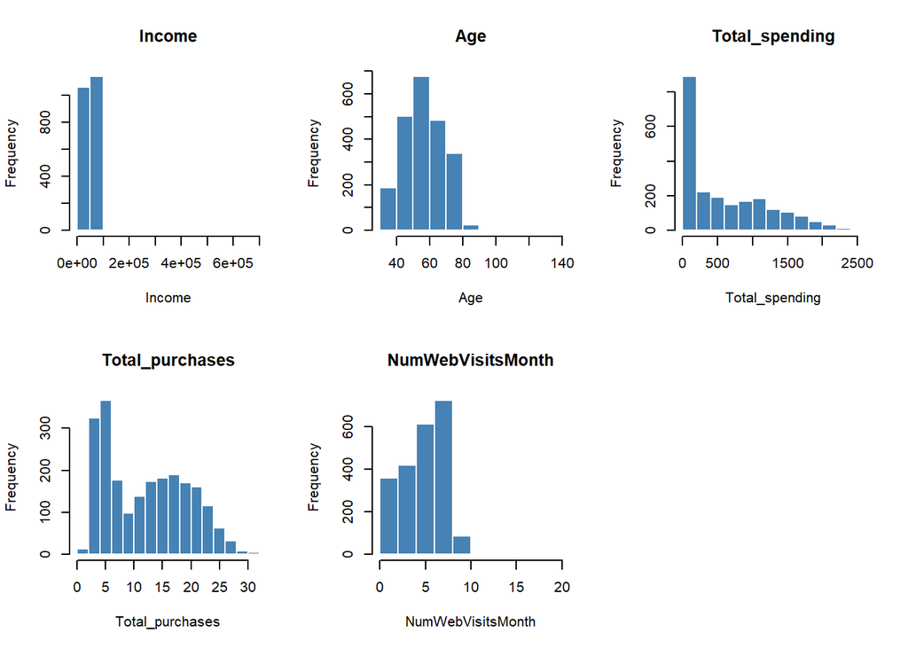

```r
# Istogrammi
par(mfrow = c(2, 3))
for (var in names(cluster_data)) {
  hist(cluster_data[[var]],
       main = var,
       xlab = var,
       col = "steelblue",
       border = "white")
}
par(mfrow = c(1, 1))
```

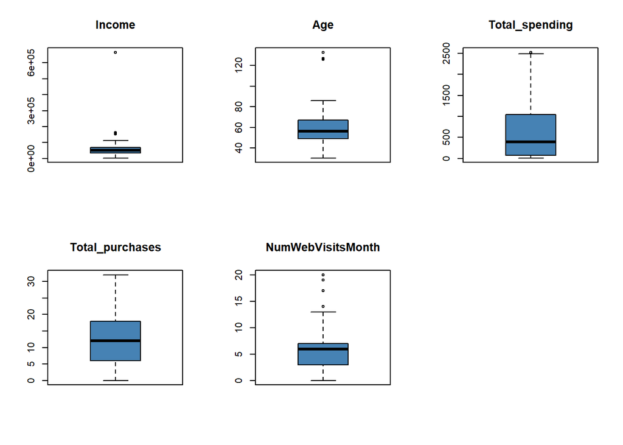

```r
# Boxplot per outlier
par(mfrow = c(2, 3))
for (var in names(cluster_data)) {
  boxplot(cluster_data[[var]],
          main = var,
          col = "steelblue")
}
par(mfrow = c(1, 1))
```

## 🔹 Correlazione

- Costruire scatterplot e matrice di correlazione tra le principali variabili quantitative; che relazioni emergono?

```r
# Matrice di correlazione
round(cor(cluster_data, use = "complete.obs"), 2)
```

```
##                   Income   Age Total_spending Total_purchases NumWebVisitsMonth
## Income              1.00  0.16           0.67            0.63             -0.55
## Age                 0.16  1.00           0.11            0.17             -0.12
## Total_spending      0.67  0.11           1.00            0.82             -0.50
## Total_purchases     0.63  0.17           0.82            1.00             -0.43
## NumWebVisitsMonth  -0.55 -0.12          -0.50           -0.43              1.00
```

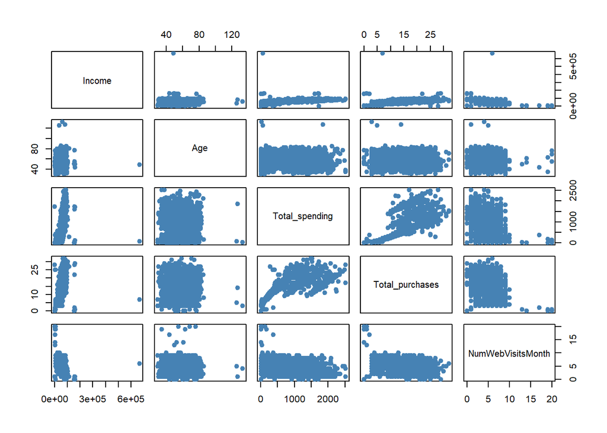

```r
# Scatterplot matrix
pairs(cluster_data, pch = 19, col = "steelblue")
```

## 🔹 Matrici delle distanze

- Calcolare la matrice delle distanza utilizzando la distanza euclidea e distanza di Manhattan;

```r
# Distanza euclidea
dist_euclidean <- dist(cluster_scaled, method = "euclidean")

# Distanza di Manhattan
dist_manhattan <- dist(cluster_scaled, method = "manhattan")
```

## 💥 Risposta:

- **Distanza euclidea**: misura la distanza “in linea d’aria” tra le osservazioni nello spazio standardizzato.
- **Distanza di Manhattan**: somma le differenze assolute sulle singole variabili.

## 🔹 Dissimilarità per variabili qualitative

- Che misura di *dissimilarità* è appropriato usare con variabili qualitative?

## 💥 Risposta:

**Per variabili qualitative**, la misura di dissimilarità appropriata è la **distanza di Gower**, che combina variabili quantitative e qualitative in un’unica metrica (utile per PAM con dati misti).

## PARTE C: Clustering gerarchico

```r
# Per visualizzare meglio i dendrogrammi, prendo un campione di 100 osservazioni
set.seed(123)
idx <- sample(1:nrow(cluster_scaled), 100)
cluster_subset <- cluster_scaled[idx, ]
dist_subset <- dist(cluster_subset)
```

## 🔹 Applicazione dei metodi

- Applicare clustering gerarchico utilizzando *single linkage, complete linkage, average linkage* e *Ward*;

```r
# Single linkage
hc_single <- hclust(dist_subset, method = "single")

# Complete linkage
hc_complete <- hclust(dist_subset, method = "complete")

# Average linkage
hc_average <- hclust(dist_subset, method = "average")

# Ward
hc_ward <- hclust(dist_subset, method = "ward.D2")
```

## 🔹 Dendrogrammi

- Per ciascun metodo rappresentare il dendrogramma; cosa si può osservare?

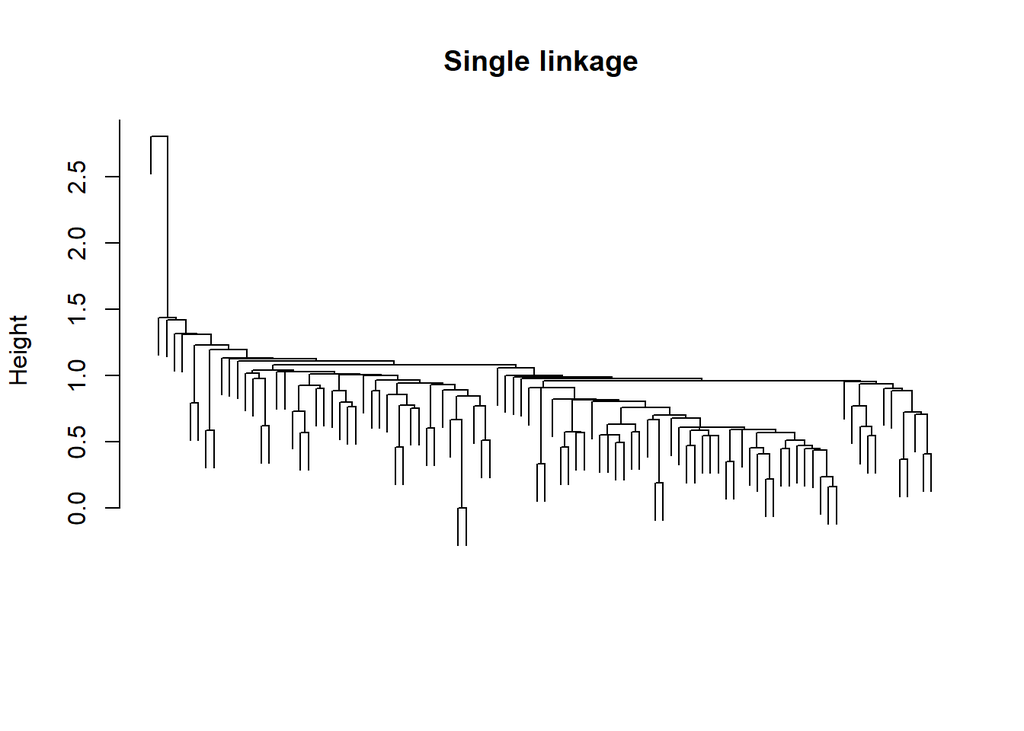

```r
# Single linkage
plot(hc_single, labels = FALSE, main = "Single linkage", xlab = "", sub = "")
```

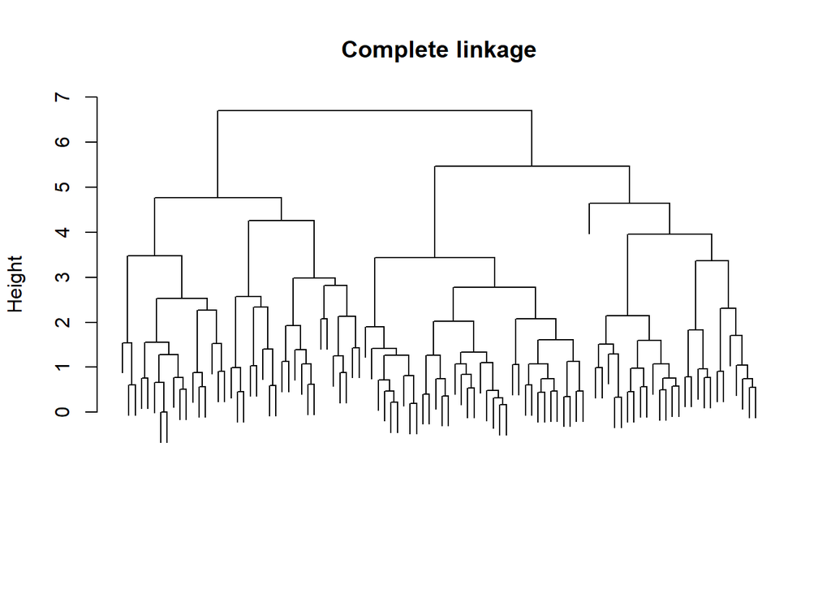

```r
# Complete linkage
plot(hc_complete, labels = FALSE, main = "Complete linkage", xlab = "", sub = "")
```

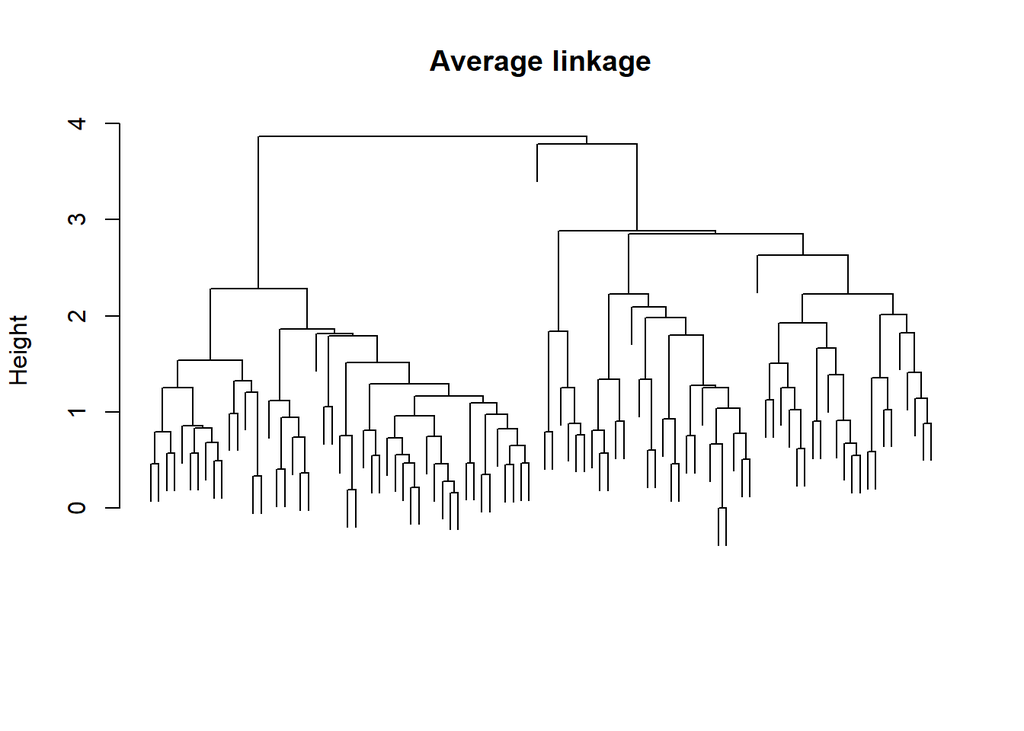

```r
# Average linkage
plot(hc_average, labels = FALSE, main = "Average linkage", xlab = "", sub = "")
```

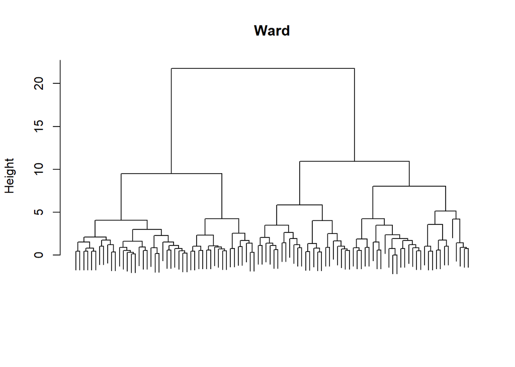

```r
# Ward
plot(hc_ward, labels = FALSE, main = "Ward", xlab = "", sub = "")
```

## 💥 Risposta:

- **Single linkage**: produce cluster “a catena” (chaining effect), con osservazioni collegate progressivamente. I cluster risultano poco compatti e spesso sbilanciati.
- **Complete linkage**: tende a formare cluster più compatti e bilanciati rispetto al single linkage. Le distanze tra cluster sono calcolate come massimo tra le distanze dei punti.
- **Average linkage**: rappresenta un compromesso tra single e complete. I cluster sono generalmente ben bilanciati e compatti.
- **Ward**: minimizza la varianza all’interno dei cluster. Produce cluster sferici e compatti, ed è spesso il metodo più interpretabile.

## 🔹 Scelta del numero di cluster con Ward

- Utilizzando il metodo di Ward, scegliere un numero appropriato di cluster;

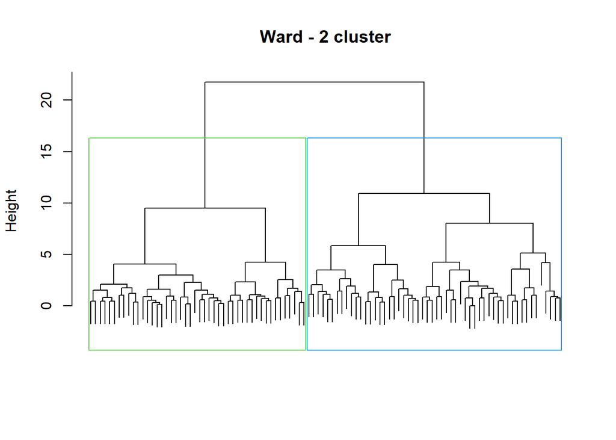

```r
# Dendrogramma con taglio a 2 cluster
plot(hc_ward, labels = FALSE, main = "Ward - 2 cluster", xlab = "", sub = "")
rect.hclust(hc_ward, k = 2, border = c(3, 4))
```

```r
# Taglio per ottenere i cluster
ward_clusters <- cutree(hc_ward, k = 2)
table(ward_clusters)
```

```
## ward_clusters
##  1  2
## 46 54
```

```r
# Medie per cluster
aggregate(cluster_data[idx, ], by = list(Cluster = ward_clusters), FUN = mean)
```

```
##   Cluster   Income      Age Total_spending Total_purchases NumWebVisitsMonth
## 1       1 34242.61 58.04348       85.95652        5.543478          6.173913
## 2       2 67458.09 58.62963     1205.68519       19.000000          3.962963
```

## PARTE D: K-means

## 🔹 Scelta del numero di cluster

- Applicare l’algoritmo K-means ai dati standardizzati; determinare un numero appropriato di cluster considerando:
  - il *metodo del gomito* (Elbow Method);
  - il *silhouette score*;

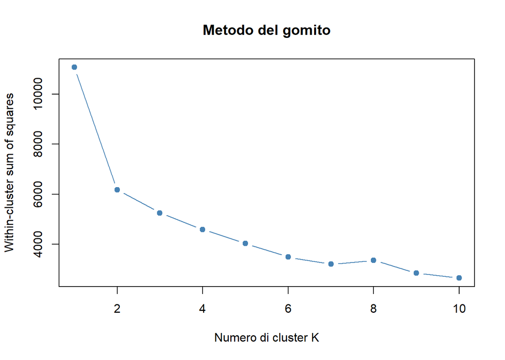

```r
# Imposto seed per riproducibilità
set.seed(123)

# Metodo del gomito
wss <- sapply(1:10, function(k) {
  kmeans(cluster_scaled, centers = k, nstart = 25)$tot.withinss
})

plot(1:10, wss,
     type = "b",
     pch = 19,
     col = "steelblue",
     xlab = "Numero di cluster K",
     ylab = "Within-cluster sum of squares",
     main = "Metodo del gomito")
```

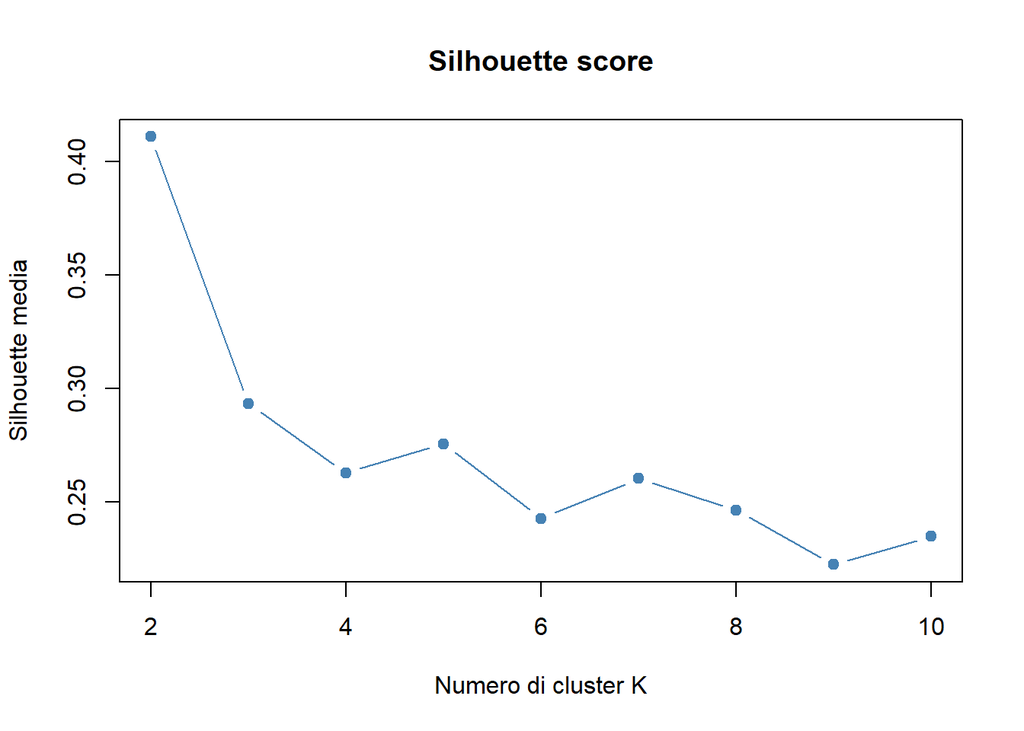

```r
# Silhuoette score
library(cluster)
sil_values <- numeric(9)
for (k in 2:10) {
  km_temp <- kmeans(cluster_scaled, centers = k, nstart = 25)
  sil <- silhouette(km_temp$cluster, dist(cluster_scaled))
  sil_values[k - 1] <- mean(sil[, 3])
}

plot(2:10, sil_values,
     type = "b",
     pch = 19,
     col = "steelblue",
     xlab = "Numero di cluster K",
     ylab = "Silhouette media",
     main = "Silhouette score")
```